# Hi there 👋

# 🇵🇪 **Andree Valle-Campos** (él/he/his)

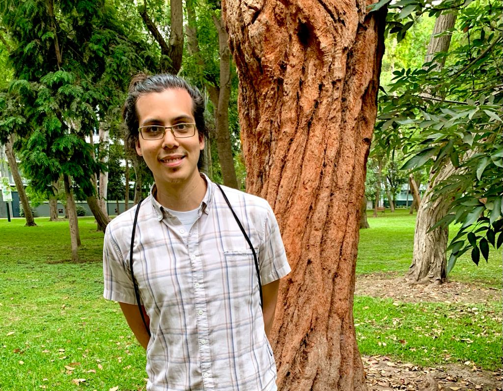

## **I’m a geneticist skilled in health data science**

🏗️ I take **data** problems to learn new **tools** in the route to solve them, **motivated** by causal questions and **reproducible** research.

🔓 Continuously integrating **open** science, **software** development and **teaching** online better practices!

🌱 Interested in **systems** developmental biology, **quantitative** and **bioengineering** approaches, living matter **configuration** principles.

⛑️ This website contains **links** to all my (reusable) scientific **contributions**. Here is a structured **pdf** version of my [cv/resume](https://github.com/avallecam/resume/raw/main/cv-andree_vallecampos.pdf).

# 🗂️

## bio

#### now

- 💻 Freelancer;
- ✒️ Writing my thesis manuscripts and grad school applications!
- ✨ Crafted last [serosurvey](https://avallecam.github.io/serosurvey/) package 📦;
- ⭐ Coordinator in a last [outbreak analysis course](https://mobile.twitter.com/cdc_peru/status/1392099144689401857) in [latinamerica](https://twitter.com/avallecam/status/1413682203041701889?s=20);

#### bio

- 🏠 I am a computationally-oriented **geneticist** formally trained in quantitative **epidemiological research**;
- 📚 I have my list of academic **publications** in [orcid](https://orcid.org/0000-0002-7779-481X) and [scholar](https://scholar.google.com/citations?user=p1Tq4esAAAAJ&hl=es);
- 📜 I did my [MSc](https://github.com/avallecam/movmal) research about human mobility and malaria history in the peruvian amazon (**UPCH, 2018**);
- 📜 I did my [BSc](https://github.com/avallecam/abnomic) research about antibody responses and severe vivax malaria with protein microarrays (**UNMSM, 2015**);

#### also

- ⚙️ I am a proficient **`R` user**, expert data **wrangler** and **visualization** enthusiast.
- ☁️ I am fluid with using `bash` for **automation** and `shh` **remote** computing.
- 📀 I have made analysis **workflows** with **omic**, serological, gps, health service and **spatio-temporal** data;
- 🥤 I have complemented my **training** with awesome communities: [ictp-saifr](https://www.ictp-saifr.org/v-southern-summer-school-on-mathematical-biology/), [codata-rda](https://www.datascienceschools.org/), [recon](https://www.repidemicsconsortium.org/), [metadocencia](https://www.metadocencia.org/cursos/);

#### contact

- 💬 Ping me about **applied biostatistics**, **data science education**, and **reproducible research**;
- 📫 Reach me: avallecam@gmail.com;
- 🐤 Tweet me: [`@avallecam`](https://twitter.com/avallecam).

## resources

#### R packages 📦

status: learning in progress!

- 💙 [serosurvey](https://avallecam.github.io/serosurvey/) - estimate prevalences.
- 🚧 incidenceflow - epidemic workflows.
- 💚 [covid19viz](https://avallecam.github.io/covid19viz/) - access covid-19 data.
- 💚 powder - tidy power analysis.
- 🚧 sitreper - situational reports in peru.
- 💚 cdcper - funciones para el cdc perú.
- 💚 epichannel - create endemic channels.
- 💚 epitidy - table and model outputs.
- 🚧 [epihelper](https://avallecam.github.io/epihelper/) - custom (cool) funtions.

#### dashboards

- 💾 data exploration: https://avallecam.shinyapps.io/data_qc/
- 💾 [ES] data exploration: https://avallecam.shinyapps.io/data_qc-es/
- 💾 disease surveillance: https://avallecam.github.io/shiny-server/per/index.html

#### templates

- ♻️ tables: https://bit.ly/epitables
- ♻️ manuscripts: https://bit.ly/draftmanuscript
- ♻️ survey-forms: https://ee.kobotoolbox.org/x/oW0aWyxX
- ♻️ linear regression: https://bit.ly/gglinearregression
- ♻️ website: https://github.com/avallecam/avallecam.github.io

#### lifeguards

- 📑 I have a code **cheatsheet** full of reproducible examples in [gist](https://gist.github.com/avallecam);
- 🌍 I have contributed **answers** for the [stackoverflow](https://stackoverflow.com/users/6702544/avallecam) community;
- 💌 I collect helpful **links** for a lot of topics in a public [trello board](https://trello.com/b/xtO9VP36/scibites).

#### texts

- 🔖 **[opinion][ES] Data and transparency to fight against the coronavirus, 2020** https://ojo-publico.com/1718/datos-y-transparencia-para-luchar-contra-el-coronavirus
- 🔖 **[editorial][ES] Health Data Science: Applications at CDC Perú, 2019** https://avallecam.github.io/health_data_science_editorial/

## talks

### talks

🔔 **serosurvey: Serological Surveys and Prevalence Estimation Under Misclassification, 2021**

- 🍭 slides: https://bit.ly/serosurvey-user21
- 🍿 video: https://youtu.be/0mugb1mE68g
- 🍲 repo: https://github.com/avallecam/serosurvey-user21

🔔 **[ES] Introduction to spatial analysis, 2021**

- 🍭 slides: https://bit.ly/espacial2021

🔔 **[ES] Analysis of #multiple epidemics and prevalences with R and purrr, 2020**

- 🍭 slides: https://bit.ly/bbslisepi
- 🍿 video: https://youtu.be/mxX8tDmC45E

🔔 **[ES] Causal questions for hypothetical interventions, 2020**

- 🍭 slides: https://bit.ly/casual_question

🔔 **[ES] Hypothesis testing with nonparametric statistical methods, 2020**

- 🍭 slides: https://bit.ly/noparam2020
- 🍿 video: https://youtu.be/1MTt1Ro-OP4

🔔 **[ES] Epidemiological analysis of the epidemic of Guillain Barré Syndrome in Peru, 2019**

- 💾 poster: https://raw.githubusercontent.com/avallecam/cdcperu-gt_investigacion/master/20191120-poster-SGB-INSv3.jpg
- 🍲 repo: https://avallecam.github.io/cdcperu-gt_investigacion/

🔔 **Human mobility and malaria history in a periurban community of the Peruvian Amazon, 2019**

- 💾 poster: https://raw.githubusercontent.com/avallecam/movmal/master/poster/astmh_poster-ValleAA-20191116.jpg
- 🍲 repo: https://github.com/avallecam/movmal

🔔 **[ES] R applied to epidemiology, 2019**

- 🍭 slides: https://speakerdeck.com/avallecam/r-aplicado-a-epidemiologia
- 🍿 video: https://youtu.be/C3Yqw883jrs
- 🍲 repo: https://avallecam.github.io/epiapli2019/

## lectures

### lectures

📌 **[ES] Data analysis in epidemiological surveillance II: spatial analysis, 2021**

- 🍭 slides: http://bit.ly/episurv2021parte2
- ⚒️ tutorial: https://rpubs.com/avallecam/episurv2021parte2

📌 **[ES] Data analysis in epidemiological surveillance I: time, space, person and epidemic curve, 2021**

- ⚒️ tutorial: https://rpubs.com/avallecam/episurv2021parte1
- ⚒️ extra: endemic channel https://rpubs.com/avallecam/episurv2021

📌 **[ES] Visualizing public health and field epidemiology data, 2021**

- 🍭 slides: https://bit.ly/epiviz2021

📌 **[ES] Algorithms for the detection of aberrations in epidemiological surveillance, 2020**

- 🍭 slides: https://avallecam.github.io/episurv2020/0101-surveillance.html#1

📌 **[ES] Tardigrades and Bioinformatics in Horizontal Gene Transfer, 2016**

- 🍭 slides: https://bit.ly/tardigate2016

📌 **[ES] Gene regulatory networks, 2015-2017**

- 🍭 slides: https://bit.ly/biomath2017_
- ⚒️ tutorial: https://github.com/avallecam/gene_regulatory_networks/blob/main/GRN_py/UNAM_mat2.ipynb
- 🍲 repo: https://github.com/avallecam/gene_regulatory_networks

## workshops

### workshops

🖐️ **[ES] Introduction to statistical analysis of epidemics, 2021**

- 🍭 slides: https://bit.ly/cursoepidemias-analisisbrote
- ⚒️ tutorial: https://www.reconlearn.org/post/real-time-response-1-spanish.html

🖐️ **[ES] Introduction to R and Rstudio, 2021**

- 🍭 slides: https://bit.ly/cursoepidemia-intror
- ⚒️ tutorial: https://www.reconlearn.org/post/practical-intror-spanish.html

🖐️ **[ES] Introduction to ggplot2, 2021**

- 🍭 slides: https://bit.ly/r08ggplot2
- 🍲 repo: https://github.com/avallecam/workshop_ggplot2

🖐️ **[ES] Introduction to the use of R projects, 2021**

- 🍭 slides: https://bit.ly/r02proyectos
- 🍲 repo: https://cdcperucursos.github.io/cursorcdc1.html

🖐️ **[ES] Epidemiological analysis in R, 2019**

- 🍭 slides: https://avallecam.github.io/epistat2019/r02.html#1
- 🍲 repo: https://avallecam.github.io/epistat2019/

🖐️ **[ES] Inferential statistics in R, 2019**

- 🍭 slides: https://avallecam.github.io/biostat2019/00-biostat2019-slides.html#1
- 🍲 repo: https://avallecam.github.io/biostat2019/

🖐️ **[ES] Microarray analysis with Tidyverse and Bioconductor, 2019**

- 🍲 repo: https://github.com/avallecam/bioinfo2019

🖐️ **[ES] Reproducible Science and Microarray Analysis, 2017**

- 🍭 slides: https://bit.ly/reproscience-intro
- ⚒️ tutorial: https://avallecam.github.io/bioinfo2017/biocmicro.nb.html
- 🍲 repo: https://avallecam.github.io/bioinfo2017/

## about

### about me

- 🏊 I was a [swimmer (lane #5)](https://www.youtube.com/watch?v=fN7sJPFeJcw);
- 🎬 I love watching [musical videos](https://youtube.com/playlist?list=PLDHw5KzS-qvL90chbF74RS3fAU5JdtVzZ);
- 🇵🇪 I have a playlist of [peruvian music](https://youtube.com/playlist?list=PLDHw5KzS-qvKv1z5CBELuQnqanqfZ4WSy);
- 🗃️ I store [memories](https://www.youtube.com/channel/UCvbhEkxtIVA9ldfhqDFALTA/playlists) in a couple more;
- 🎼 I occasionally play guitar🎸|piano🎹;
- 🖤 I read a manga called [berserk](https://readberserk.com/chapter/berserk-chapter-a0/);
- 🌠 I feed a wishlist in [elfster](https://www.elfster.com/profile/097d261f-1196-45a1-a4b4-12e0b245ce2d/wish-lists/be4efeaf-b9e7-465d-bcac-65ef129be519/);
- 🎨 I appreciate visiting [art galleries](https://coleccion.mali.pe/collections), [unexpected](https://maclima.pe/project/visitante-fernando-de-szyszlo/) findings [occur](https://www.metmuseum.org/es/art/collection/search/267838);
- 🥦 I got curious on physical biology after: [goodwin](https://libgen.rs/book/index.php?md5=CBFF641AD61645A284EE4566EB2B0146), [bejan](https://libgen.rs/book/index.php?md5=F9D8AF5DCDF3C74ED2C34A56C7522E22), [leibler](https://journals.aps.org/prx/abstract/10.1103/PhysRevX.5.041014);
- 🌩️ I enjoy reading dialectical materialism: [politzer](https://libgen.rs/book/index.php?md5=BDA5E8E26C125758A4C809D3C74F2136), [fromm](https://libgen.rs/book/index.php?md5=2B4A32A41996AEFB7D810F90A67EAEE2), [engels](https://libgen.rs/book/index.php?md5=64BA70A56CE5241A442C2056B3766995);
- 🎲 I like listening to [radiohead](https://youtu.be/I4pezRt9boY), [apparat](https://youtu.be/NOol5V4Tlk8), [niños sin](https://youtu.be/S5vKPHigWqY) [smartphones](https://youtu.be/QI9mksVqivg);
- 🍥 I am [learning](https://www.a11yproject.com/) to design [accessible](https://user2021.r-project.org/participation/accessibility/) outputs.

#### avallecam

- 🌞 Stands for **a**ndree **valle** **cam**pos.
- 💕 I intentionally used **cam** in reference to my [chinese](https://www.mychinaroots.com/surnames/detail?word=Campos) ancestry